# How to include statisical analysis in ggplot

Anders Jensen

2026-03-27

# Introduction

I hope we can all agree that using R and RStudio is the superior way to make plots and execute data visualisation to a higher level.

If you don’t agree with that then you’re either in denial or someone who uses prism (probably from a dodgy stick) and are shouting that you can’t put stats results on your plots.

You only think that because you haven’t used **rstatix** and **ggpubr**.

These two package do different things:

rstatix - A pipe-friendly statistical pipeline ggpubr - A package to include the results from rstatix onto a ggplot

# How to install them

Installation is ridiculously easy:

```r
install.packages("rstatix")
install.packages("ggpubr")

library(ggpubr)
library(rstatix)
```

# The basics of rstatix

So as I mentioned above, rstatix is a pipe-friendly statistical package for RStudio.

This is an absolute godsend for people who have forgotten how to code in base R like myself and rely on the tidyverse and specifically dplyr.

The structure of the data needs to be the same as if you were using base R. So imagine an example with the iris dataset where we want to do a t_test on sepal.length between setosa and versicolor:

```r
# load data
data("iris")

# set data up
df <- iris %>%
  filter(Species != "virginica") %>%
  mutate(Species = as.character(Species))

# using rstatix
df_stats <- df %>%
  rstatix::t_test(formula = Sepal.Length~Species)

# Show result
df_stats
```

```
## # A tibble: 1 × 8
##   .y.          group1 group2        n1    n2 statistic    df        p
## * <chr>        <chr>  <chr>      <int> <int>     <dbl> <dbl>    <dbl>
## 1 Sepal.Length setosa versicolor    50    50     -10.5  86.5 3.75e-17
```

So as you can see when you use rstatix the results from the statistical test are not stored in some dingy list but instead in a nice clean dataframe. In the above example you can also do this in one step as seen below.

```r
# This works as well
df <- iris %>%
  filter(Species != "virginica") %>%
  mutate(Species = as.character(Species)) %>%
  rstatix::t_test(formula = Sepal.Length~Species)
```

# Additional rstatix functions

So now you have your stats result you will need to start prepping that data to go on your plots.

Just by looking at the df_stats output you can think about what it is missing:

1. No X position
2. No Y position
3. No significance stars (****, ***,** ,* , ns)

Fortunately adding all of these things is very simple:

```r
# load data
data("iris")

# set data up
df <- iris %>%
  filter(Species != "virginica") %>%
  mutate(Species = as.character(Species))

# using rstatix
df_stats <- df %>%
  rstatix::t_test(formula = Sepal.Length~Species) %>%
  add_significance() %>%
  add_xy_position()

df_stats
```

```
## # A tibble: 1 × 13
##   .y.     group1 group2    n1    n2 statistic    df        p p.signif y.position
##   <chr>   <chr>  <chr>  <int> <int>     <dbl> <dbl>    <dbl> <chr>         <dbl>
## 1 Sepal.… setosa versi…    50    50     -10.5  86.5 3.75e-17 ****           7.14
## # ℹ 3 more variables: groups <named list>, xmin <dbl>, xmax <dbl>
```

So now you should be able to see all of these things have been added in the dataframe.

# Using ggpubr

Okay so now I am going to show how to add this information to the ggplot

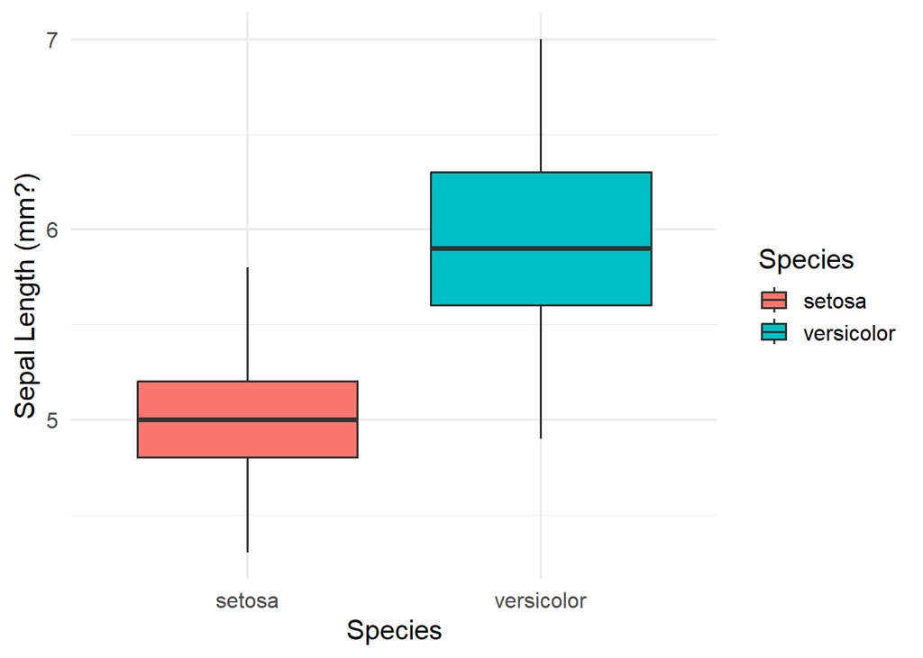

```r
# load data
data("iris")

# set data up
df <- iris %>%
  filter(Species != "virginica") %>%
  mutate(Species = as.character(Species))

# using rstatix
df_stats <- df %>%
  rstatix::t_test(formula = Sepal.Length~Species) %>%
  add_significance() %>%
  add_xy_position()

# make the plot
ggplot(df, aes(x = Species, y = Sepal.Length))+
  geom_boxplot(aes(fill = Species))+
  theme_minimal(base_size = 15)+
  labs(x = "Species", y = "Sepal Length (mm?)")
```

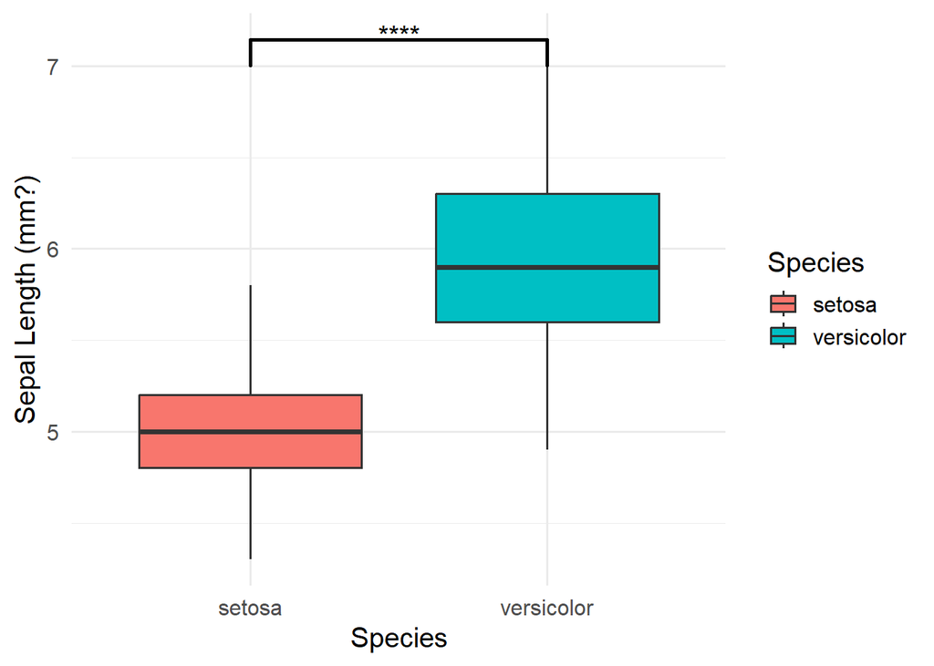

```r
# add the statistics onto the plot
ggplot(df, aes(x = Species, y = Sepal.Length))+
  geom_boxplot(aes(fill = Species))+
  theme_minimal(base_size = 15)+
  labs(x = "Species", y = "Sepal Length (mm?)")+
  ggpubr::stat_pvalue_manual(data = df_stats,
                             label = "p.signif", # just 'p' for actual number
                             label.size = 5, # size of stars
                             color = "black",
                             bracket.size = 1, # width of the lines
                             tip.length = 0.05) # how far vertical lines go
```

That’s the absolute basics on how to use the two R packages. There are a few other things to consider that you may come across.

# External statistics

Say you are doing some fancy statistics using a different R package that isn’t available in rstatix. That situation is completely understandable and many people are far more comfortable using the package they know.

You can still use rstatix and ggpubr by simply adding the result of that statistical test to the df_stats data frame.

You can do this by either first running a similar statistical test and changing just the value or by making a blank dataframe with the correct column names and inputting the p value you want to use.

For an example I am going to use the same example as above, however I am going to use base R to do a t_test.

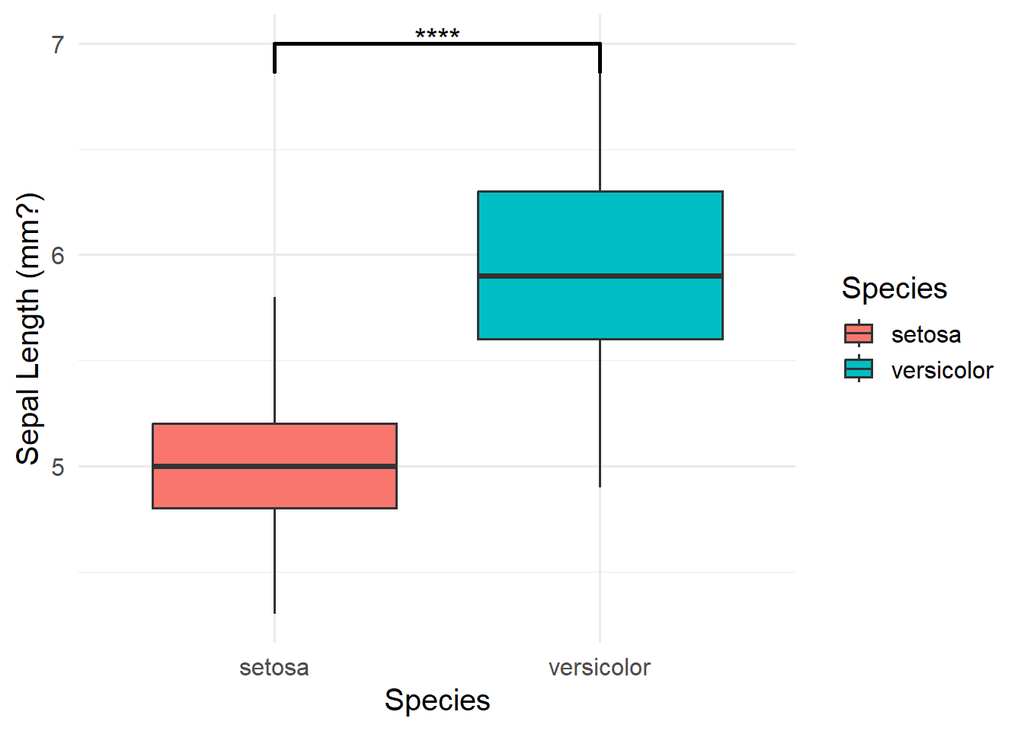

```r
# load data
data("iris")

df <- iris %>%
  mutate(Species = as.character(Species)) %>%
  filter(Species != "virginica")

# Run test and extract value
t_test <- t.test(formula = Sepal.Length~Species, data = df)
p_value <- t_test$p.value

# Make an rstatix dataframe
r_statix <- data.frame(.y. = NA,
                       group1 = NA,
                       group2 = NA,
                       n1  = NA,
                       n2 = NA,
                       statistic = NA,
                       df = NA,
                       p = NA,
                       p.signif = NA,
                       y.position = NA,
                       groups = NA,
                       xmin = NA,
                       xmax = NA)

# Retrieve a reactive y position
y_value <- max(df$Sepal.Length)

# Input the things I need
r_statix_final <- r_statix %>%
  mutate(p = p_value,
         p.signif = case_when(p < 0.0001 ~ "****",
                              p < 0.001 ~ "***",
                              p < 0.01 ~ "**",
                              p < 0.05 ~ "*",
                              TRUE ~ "ns"),
         xmin = 1,
         xmax = 2,
         y.position = y_value,
         group1 = "setosa",
         group2 = "versicolor")


# Make the plot
ggplot(df, aes(x = Species, y = Sepal.Length))+
  geom_boxplot(aes(fill = Species))+
  theme_minimal(base_size = 15)+
  labs(x = "Species", y = "Sepal Length (mm?)")+
  ggpubr::stat_pvalue_manual(data = r_statix_final,
                             label = "p.signif", # just 'p' for actual number
                             label.size = 5, # size of stars
                             color = "black",
                             bracket.size = 1, # width of the lines
                             tip.length = 0.05) # how far vertical lines go
```

A little bit more complicated but this shows that you can use any p-value you retrieve from a statistical test and add it to a ggplot.

Sometimes you may find the x values don’t quite line up as you would expect/want them to. In those cases have a go changing the xmin and xmax values untill they line up on the plot.

# Conclusion

Hopefully you now feel confident to add statistical analysis results to your ggplots.

If you are having issues feel free to email me (hlajens2@liverpool.ac.uk).